# Practice Exam 1

Phil Anderson

October 3, 2017

```r
# Install our third-party modules
library("tidyverse")
```

First, let’s read in our data

```r
pref <- read.csv("C:/Users/Philip/Schools/TAMU/STAT_636/exam_prep/consumer_pref.csv")

names(pref) <- tolower(names(pref))
str(pref)
```

```
## 'data.frame':    100 obs. of  5 variables:
##  $ taste : num  -0.502 0.451 -2.286 -0.806 -0.365 ...
##  $ value : num  -0.0669 -0.3514 0.6047 0.503 1.0451 ...
##  $ flavor: num  -0.425 0.957 -1.714 -0.848 -0.286 ...
##  $ snack : num  -0.0215 0.876 -0.7411 0.5018 0.049 ...
##  $ energy: num  -0.379 0.196 0.86 0.938 0.523 ...
```

## Question 1-A

Generate QQ Plots for each variable

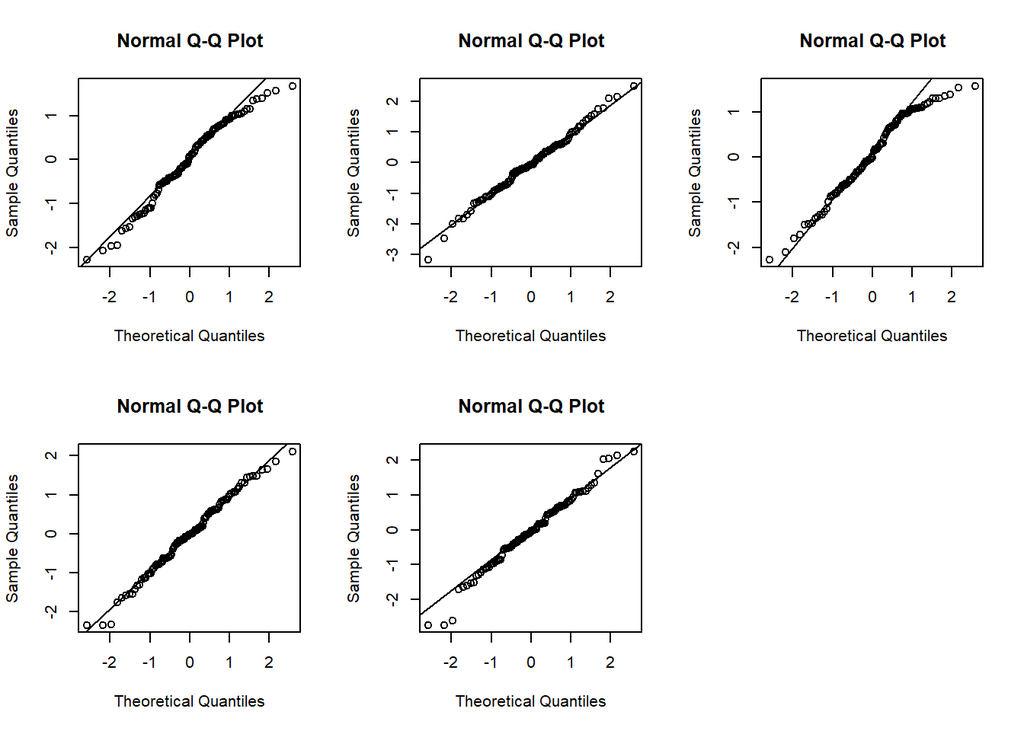

```r
par(mfrow=c(2,3))
qqnorm(pref$taste); qqline(pref$taste)
qqnorm(pref$value); qqline(pref$value)
qqnorm(pref$flavor); qqline(pref$flavor)
qqnorm(pref$snack); qqline(pref$snack)
qqnorm(pref$energy); qqline(pref$energy)
```

## Question 1-B

```r
(x_bar <- colMeans(pref))
```

```
##       taste       value      flavor       snack      energy
## -0.01479661 -0.05071000  0.03410270 -0.03532974 -0.05918269
```

```r
(S <- var(pref))
```

```
##              taste       value      flavor     snack      energy
## taste   0.82849643 -0.08901962  0.79283175 0.3502193 -0.12382215
## value  -0.08901962  1.02206837  0.02437169 0.6956363  0.88508813
## flavor  0.79283175  0.02437169  0.83234577 0.4238329 -0.02667602
## snack   0.35021933  0.69563632  0.42383292 0.9395577  0.69530189
## energy -0.12382215  0.88508813 -0.02667602 0.6953019  0.98861657
```

```r
(p <- ncol(pref))
```

```
## [1] 5
```

```r
(n <- nrow(pref))
```

```
## [1] 100
```

```r
pref_eig <- eigen(S)
# axes given by:
pref_eig$vectors
```

```
##            [,1]       [,2]       [,3]       [,4]         [,5]
## [1,] -0.1360208  0.6573078 -0.1222166  0.1591158 -0.713575591
## [2,] -0.5666361 -0.2546678 -0.6678756 -0.3973080 -0.100778901
## [3,] -0.1993738  0.6325132 -0.2529460  0.1284351  0.692603673
## [4,] -0.5613398  0.1516886  0.6793851 -0.4465146  0.030803146
## [5,] -0.5527835 -0.2828575  0.1160153  0.7752146 -0.002192531
```

```r
#half-lengths given by:
sqrt(pref_eig$values) * sqrt( (p * (n - p)) / (n * (n - p)) * qf(1-0.05,p, n-p )  )
```

```
## [1] 0.54398855 0.45088988 0.13321743 0.10996047 0.05973888
```

## Question 1-C

Report 95% Bonferroni-based simultaneous confidence intervals for our p-variables. How would you interpret this collection of confidence intervals, in terms of the coverage probabilities?

```r
# note that we are using alpha=0.025 for the two-sided coverage
# also note that we are taking the diagonal elements of the variance-covariance matrix

bon_mat <- matrix(NA, nrow=p, ncol=2)

for (i in 1:p) {
bon <- x_bar[i] + c(-1, 1) * qt(1 - 0.025 / p, n - 1) * sqrt(S[i,i] / n)
bon_mat[i, ] <- bon
  }

cbind(bon_mat[,1], x_bar, bon_mat[,2])
```

```
##                         x_bar
## taste  -0.2538567 -0.01479661 0.2242635
## value  -0.3162328 -0.05071000 0.2148128
## flavor -0.2055121  0.03410270 0.2737175
## snack  -0.2899093 -0.03532974 0.2192498
## energy -0.3203241 -0.05918269 0.2019587
```

These intervals are constructed such that we are 95% confident that they contain the true means. Note that this is not saying that we have a 95% probability that the true mean is contained within the interval.

## Question 1-D

Carry out Hotelling’s multivariate generalization of the t-test for the null hypothesis that the mean vector is equal to the null vector.

```r
(mu_0 <- rep(0,p))
```

```
## [1] 0 0 0 0 0
```

```r
# gather our test statistic (observed)
(T2_obs <- n * t(x_bar - mu_0) %*% solve(S) %*% (x_bar - mu_0))
```

```
##          [,1]
## [1,] 5.127638
```

```r
# gather our p-value
1 - pf( (n - p) / ((n - 1) * p) * T2_obs , p, n-p )
```

```
##           [,1]
## [1,] 0.4316704
```

We do not see evidence that our p-value is significantly different from the zero vector.

## Question 1-E

Use the bootstrap algorithm to compute the p-value from the previous problem.

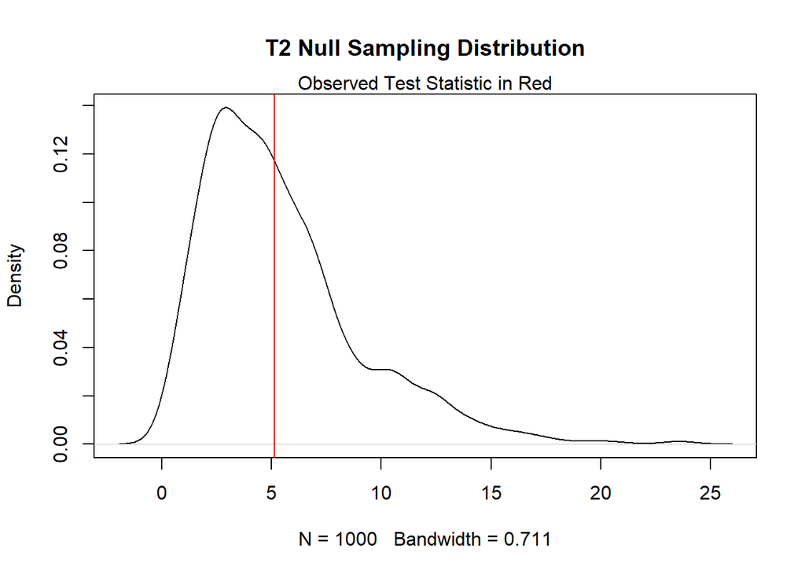

```r
B <- 1000 # number of epochs
set.seed(101)

# recall that T2_obs is our observed test statistic for this procuedure

# rescale our data vector
pref_0 <- scale(pref, center=T, scale=F)
T2_output <- numeric(B)

for (i in 1:B){
  temp <- pref_0[sample(1:n, replace=T),]
  x_bar_temp <- colMeans(temp)
  S_temp <- var(temp)
  T2_b <- drop(n * t(x_bar_temp - mu_0) %*% solve(S_temp) %*% (x_bar_temp - mu_0))
  T2_output[i] <- T2_b
}

# let's view our sampling distribution
plot(density(T2_output), main="T2 Null Sampling Distribution")
mtext("Observed Test Statistic in Red")
abline(v=drop(T2_obs), col="red")
```

```r
sum(T2_output >= drop(T2_obs)) / 1000
```

```
## [1] 0.434
```